# Turning up the Heat

Joey Hotz

February 3, 2022

In order to compare these observations, we must first import the data into R.

```r
dim(data_1939)
```

```
## [1] 365  31
```

```r
dim(data_2021)
```

```
## [1] 365  31
```

From above, we can see that both of the datasets which we have imported have 365 observations and 31 variables in total. Both of these datasets should have exactly 365 observations, as these datasets represent the weather at this weather station for each day of the year.

Although the dimensions of both of these datasets match up, we still need to check whether the actual variables themselves match.

Tables 1 and 2 below depict the names and types (in R) for each of the 31 variables in the datasets, as well as the number of present and missing values for each of the 31 variables.

Variables which were recorded at the Fort Ross weather station in 1939

|  | Variable Type | Present Values | Missing Values |
| --- | --- | --- | --- |
| Longitude (x) | double | 365 | 0 |
| Latitude (y) | double | 365 | 0 |
| Station Name | character | 365 | 0 |
| Climate ID | double | 365 | 0 |
| Date/Time | double | 365 | 0 |
| Year | double | 365 | 0 |
| Month | character | 365 | 0 |
| Day | character | 365 | 0 |
| Data Quality | logical | 0 | 365 |
| Max Temp (°C) | double | 365 | 0 |
| Max Temp Flag | logical | 0 | 365 |
| Min Temp (°C) | double | 363 | 2 |
| Min Temp Flag | character | 2 | 363 |
| Mean Temp (°C) | double | 363 | 2 |
| Mean Temp Flag | character | 2 | 363 |
| Heat Deg Days (°C) | double | 363 | 2 |
| Heat Deg Days Flag | character | 2 | 363 |
| Cool Deg Days (°C) | double | 363 | 2 |
| Cool Deg Days Flag | character | 2 | 363 |
| Total Rain (mm) | double | 303 | 62 |
| Total Rain Flag | logical | 0 | 365 |
| Total Snow (cm) | double | 303 | 62 |
| Total Snow Flag | logical | 11 | 354 |
| Total Precip (mm) | double | 303 | 62 |
| Total Precip Flag | logical | 11 | 354 |
| Snow on Grnd (cm) | logical | 0 | 365 |
| Snow on Grnd Flag | logical | 0 | 365 |
| Dir of Max Gust (10s deg) | logical | 0 | 365 |
| Dir of Max Gust Flag | logical | 0 | 365 |
| Spd of Max Gust (km/h) | logical | 0 | 365 |
| Spd of Max Gust Flag | logical | 0 | 365 |

Variables which were recorded at the Fort Ross weather station in 2021

|  | Variable Type | Present Values | Missing Values |
| --- | --- | --- | --- |
| Longitude (x) | double | 365 | 0 |
| Latitude (y) | double | 365 | 0 |
| Station Name | character | 365 | 0 |
| Climate ID | double | 365 | 0 |
| Date/Time | double | 365 | 0 |
| Year | double | 365 | 0 |
| Month | character | 365 | 0 |
| Day | character | 365 | 0 |
| Data Quality | logical | 0 | 365 |
| Max Temp (°C) | double | 320 | 45 |
| Max Temp Flag | character | 45 | 320 |
| Min Temp (°C) | double | 318 | 47 |
| Min Temp Flag | character | 47 | 318 |
| Mean Temp (°C) | double | 318 | 47 |
| Mean Temp Flag | character | 47 | 318 |
| Heat Deg Days (°C) | double | 318 | 47 |
| Heat Deg Days Flag | character | 47 | 318 |
| Cool Deg Days (°C) | double | 318 | 47 |
| Cool Deg Days Flag | character | 47 | 318 |
| Total Rain (mm) | logical | 0 | 365 |
| Total Rain Flag | logical | 0 | 365 |
| Total Snow (cm) | logical | 0 | 365 |
| Total Snow Flag | logical | 0 | 365 |
| Total Precip (mm) | double | 192 | 173 |
| Total Precip Flag | character | 173 | 192 |
| Snow on Grnd (cm) | double | 228 | 137 |
| Snow on Grnd Flag | logical | 0 | 365 |
| Dir of Max Gust (10s deg) | double | 84 | 281 |
| Dir of Max Gust Flag | character | 238 | 127 |
| Spd of Max Gust (km/h) | double | 84 | 281 |
| Spd of Max Gust Flag | character | 238 | 127 |

Based on the legend given on the Government of Canada’s Historical Weather Database, which is where these data were sourced from, the “Flag” variables are meant to give some information and context for an observation which has a missing value for a given variable

For example, the “Min Temp Flag” variable in these datasets provides some information about the minimum temperature on that day when the actual daily minimum temperature value was not recorded in the data. However, these flags still cover a wide variety of possibilities, so they are overall quite unreliable as observed values. Since these flag variables are unreliable and the limited information which they provide does not make up for the data which is missing, these flag variables will be removed from our datasets.

As we can see in Tables 1 and 2 above, the “Data Quality” variable does not have a single recorded value in either dataset, and there is no reason to keep this variable in our datasets, as it provides literally no new information.

Since we aim to determine the changes in temperature at the Fort Ross weather station between these two years, there are many variables in these data which are not relevant to our particular analysis, such as the variables containing information about the total amount of rain, snow, and precipitation on a given day, and the variables containing information about the wind.

In addition to these non-temperature variables being removed from our data, we will also remove the Heating and Cooling Degree Days variables from the two datasets. In the [Data Glossary](https://climate.weather.gc.ca/glossary_e.html) on the Government of Canada’s website, they define heating degree days as how far below 18°C the mean temperature is on a given day, and similarly, they define cooling degree days as how far the mean temperature is above 18°C. Since heating and cooling degree days are just functions of the mean temperature for the day, there is no reason to include these variables when we can access the actual mean daily temperatures at Fort Ross instead.

Distribution of Station Names

| Station Name | Frequency |
| --- | --- |
| FORT ROSS | 730 |

As shown in Table 3 above, the Station Name variable for every one of our 730 observations across our two datasets simply contains the string “FORT ROSS”. Since this variableonly ever contains one value, there is no reason to include this variable.

Frequency of different Climate ID values

| Climate ID | Frequency |
| --- | --- |
| 2402050 | 365 |
| 2402051 | 365 |

Similarly, Table 4 shows that there are only two climate ID values in our entire dataset, and these different values simply correspond to the years, as the Climate ID for this station was 2402050 in the year 1939, and it is 2402051 in the year 2021. Since this variable provides no additional information, we will also remove it from our dataset.

Lastly, we will also remove the “Date/Time” variable, as this variable has no information which is not already present in the datasets based on the day, month, and year of the observations being recorded.

Once all of these excess variables are removed from our dataset, we will have a total of 8 variables remaining in our merged dataset. After merging the two datasets into one, we will convert the Month and Day variables from characters into integers.

Table 5 below provides some information about the 8 remaining variables.

Variables of interest in the combined data

|  | Variable Type | Present Values | Missing Values |
| --- | --- | --- | --- |
| Longitude | double | 730 | 0 |
| Latitude | double | 730 | 0 |
| Day | double | 730 | 0 |
| Month | double | 730 | 0 |
| Year | double | 730 | 0 |
| MinTemp | double | 681 | 49 |
| MaxTemp | double | 685 | 45 |
| MeanTemp | double | 681 | 49 |

Of the 8 variables remaining, there are only three variables which have important values to summarize; the maximum, minimum, and mean daily temperatures which were recorded.

The basic summary statistics for each of these three variables are presented in Tables 6 and 7 below. Table 6 contains the summary statistics for the observations from 1939, whereas Table 7 contains summary statistics for the observations recorded in 2021.

Summary Statistics of temperatures at Fort Ross, Nunavut in 1939

|  | Minimum | 1st Quartile | Median | 3rd Quartile | Maximum | Mean | Variance |
| --- | --- | --- | --- | --- | --- | --- | --- |
| Minimum Daily Temperature | -43.3 | -30.0 | -20.0 | -3.3 | 4.4 | -18.306 | 207.987 |
| Maximum Daily Temperature | -38.3 | -23.3 | -12.2 | 0.6 | 11.1 | -11.871 | 196.834 |
| Mean Daily Temperature | -40.0 | -26.7 | -15.9 | -1.3 | 7.8 | -15.145 | 200.302 |

Summary Statistics of temperatures at Fort Ross, Nunavut in 2021

|  | Minimum | 1st Quartile | Median | 3rd Quartile | Maximum | Mean | Variance |
| --- | --- | --- | --- | --- | --- | --- | --- |
| Minimum Daily Temperature | -43.2 | -25.075 | -14.80 | -1.35 | 5.5 | -14.506 | 176.605 |
| Maximum Daily Temperature | -39.0 | -18.225 | -6.70 | 2.25 | 13.1 | -8.321 | 154.545 |
| Mean Daily Temperature | -41.1 | -21.675 | -11.25 | -0.30 | 8.1 | -11.442 | 163.308 |

However, it is possible that there are some external effects which have caused these data to be skewed. There are more than 40 missing observations for each of the temperatures in the data which was collected in 2021. If these observations which were not recorded fell in the colder months of the year, it is possible that the summary statistics would be skewed to be higher than the ‘true data’ for the year of 2021, as observations during the winter were not collected.

To compare the data collected in 1939 to the data which was collected in 2021, we will use a paired t-test on each of our three temperature variables, with a 95% level of confidence. We choose to use a paired t-test to compare these data as pairing the values based on the corresponding dates can help to account for changes in temperature which we would expect due to different seasons.

Paired t-tests comparing temperatures at Fort Ross, Nunavut in 1939 to temperatured recorded in 2021

|  | Test Statistic | p-value |
| --- | --- | --- |
| Minimum Daily Temperature | -9.456845 | 0 |
| Maximum Daily Temperature | -8.525376 | 0 |
| Mean Daily Temperature | -9.299892 | 0 |

Although the outputs in Table 8 show that all three paired t-tests had corresponding p-values of 0, the p-values shown in the table are slightly incorrect. However, the p-values for all three of these paired t-tests are so incredibly small that they are negligible, and with a 95% level of confidence, we are able to reject the hypothesis that these three temperature metrics have not changed in Fort Ross between 1939 and 2021.

As we saw above, these three temperature metrics all increased between 1939 and 2021, and based on the p-values displayed above, this is a statistically significant result. A likely cause of this significant increase in temperatures in Fort Ross is global warming, although the results of this t-test do not provide conclusive evidence that this was the result of global warming in particular (though that is the most likely scenario).

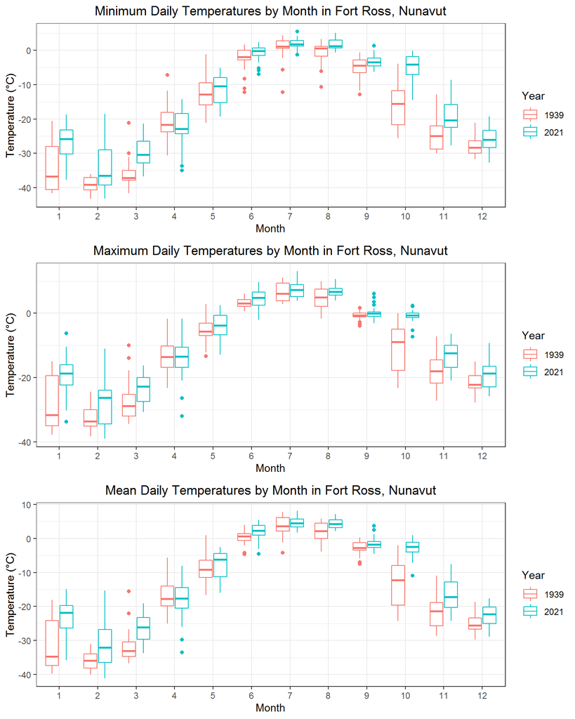

The three plots above show the distribution of the minimum, mean, and maximum daily temperatures grouped by month, for the years 1939 and 2021. As we can see in the plots above, the mean daily temperatures in 2021 were higher than in 1939 for every single month of the year, and these differences were particularly noticeable in the colder months (October through March).

With some slight outliers, the minimum and maximum daily temperatures followed a similar pattern overall, where these temperatures in 2021 were also higher than the corresponding temperatures measured in 1939 for those months, and the differences primarily occurred in the colder months again.

Based on these three plots, it would appear that there is some significant level of change in the weather patterns which occurred in Fort Ross sometime between 1939 and 2021, and these weather changes have affected the winter months more than the summer months in this area.

[interactive chart not shown]

The map above shows the locations of the Fort Ross weather station in the year 1939 (the red dot) and the year 2021 (the blue dot). Although the Fort Ross weather station has moved slightly during the 82-year period between these sets of observations being recorded, this slight movement is likely not as significant to the changes in the weather at Fort Ross as the effects of climate change in general.